# CPBS 7630 Module 2B - Dimensionality Reduction

February 18, 2016

#### Contents:

- Get cleaned data
- Principal components analysis
- Evaluation

### Get the cleaned data from Synapse

Get the drug sensitivity data from [Costello, et al. A Community Effort to Assess and Improve Drug Sensitivity Prediction Algorithms (2014)](http://www.nature.com/nbt/journal/v32/n12/full/nbt.2877.html).

```r
# ------------------------------- GET DATA -------------------------------------
# Get cleaned, log-transformed gene expression and response data from Synapse
DREAM7.data <- synGet('syn5663580')
local.file.path <- DREAM7.data@filePath

# Load the RData file
load(local.file.path)
rm(local.file.path, DREAM7.data)

# Enviroment now includes:
#############################
# expression.data - matrix of gene expression values for 30,154 genes in 39 cell lines
# drug7.response - response vector for Drug 7
# genes - vector of original gene names
# cell.lines - vector of 39 cell lines with both expression and response data
# all.response - response matrix for all drugs
#############################

# ------------------------------- FEATURE SELECTION ---------------------------

# For scaling for PCA later, we can't have any all-zero genes
expression.data <- data.frame(expression.data)
expression.data <- expression.data[, colSums(expression.data) > 0]
```

### Principal components analysis

Principal components analysis (PCA) is used for performing dimensionality reduction (feature extraction) to find novel, meaningful patterns in a data set.

#### Example 1 - toy data

To illustrate the basic principles of PCA, we will first look at a toy data set and an example adapted from [here](https://tgmstat.wordpress.com/2013/11/28/computing-and-visualizing-pca-in-r/#ref1). The `iris` data set contains data on 3 species of iris and measurements for their sepal length, sepal width, petal length and petal width.

```r
# Toy data set
data(iris)

# Log transform
iris.log <- log(iris[, 1:4])
iris.species <- iris[, 5]

# Apply PCA with stats::prcomp
iris.pca <- prcomp(iris.log,
                 center = TRUE,
                 scale. = TRUE)
# View the principal components rotation (also called loadings)
iris.pca
```

```
## Standard deviations:
## [1] 1.7124583 0.9523797 0.3647029 0.1656840
##
## Rotation:
##                     PC1         PC2        PC3         PC4
## Sepal.Length  0.5038236 -0.45499872  0.7088547  0.19147575
## Sepal.Width  -0.3023682 -0.88914419 -0.3311628 -0.09125405
## Petal.Length  0.5767881 -0.03378802 -0.2192793 -0.78618732
## Petal.Width   0.5674952 -0.03545628 -0.5829003  0.58044745
```

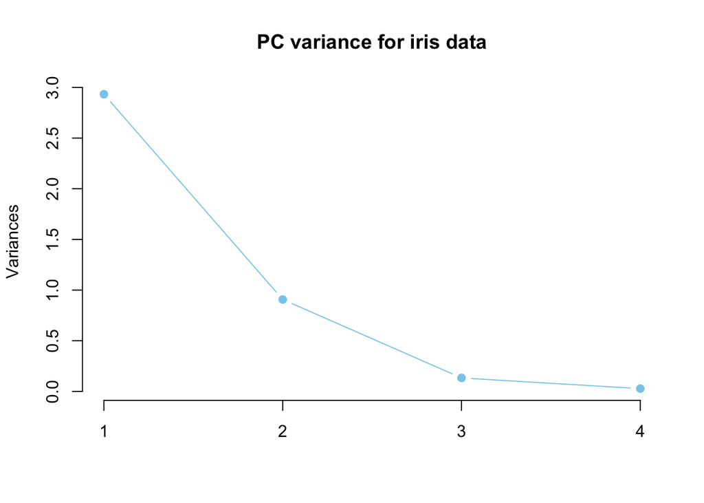

```r
# Get ggbiplot from Github if needed
# library(devtools)
# install_github("vqv/ggbiplot")

# Plot principal component variance
plot(iris.pca, type = "l", col = 'skyblue', pch = 19,
     main = 'PC variance for iris data')

# Plot PCA with ggbiplot
library(ggbiplot)
```

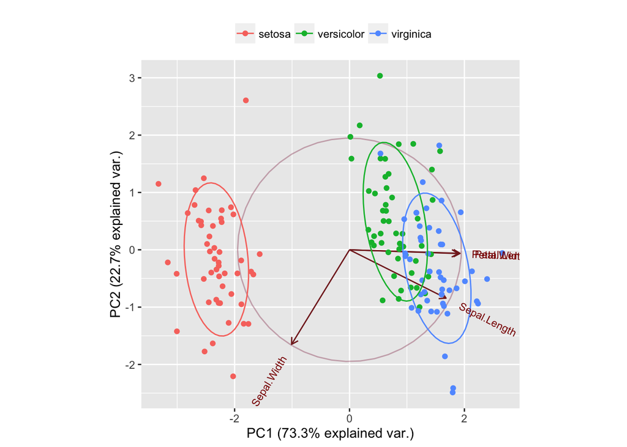

```r
g <- ggbiplot(iris.pca, obs.scale = 1, var.scale = 1,
              groups = iris.species, ellipse = TRUE,
              circle = TRUE)
g <- g + scale_color_discrete(name = '')
g <- g + theme(legend.direction = 'horizontal',
               legend.position = 'top')
print(g)
```

```r
# Summarize each of the principal components
summary(iris.pca)
```

```
## Importance of components:
##                           PC1    PC2     PC3     PC4
## Standard deviation     1.7125 0.9524 0.36470 0.16568
## Proportion of Variance 0.7331 0.2268 0.03325 0.00686
## Cumulative Proportion  0.7331 0.9599 0.99314 1.00000
```

#### Example 2 - PCA for drug synergy

In this example, we’ll use the DREAM7 drug synergy data we prepared in the first code chunk.

```r
# Apply PCA with stats::prcomp
expression.pca <- prcomp(expression.data,
                 center = TRUE,
                 scale. = TRUE)

# View the number of principal components
length(expression.pca$sdev)
```

```
## [1] 39
```

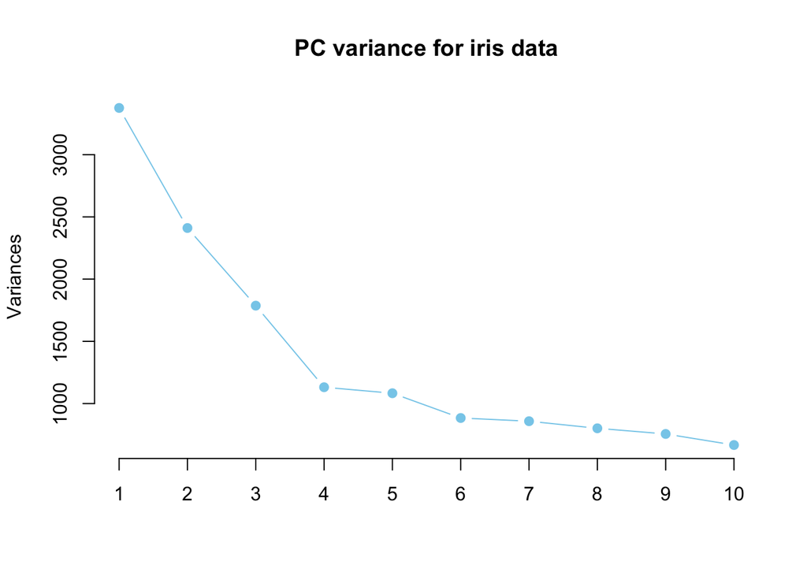

```r
# Plot principal component variance
plot(expression.pca, type = "l", col = 'skyblue', pch = 19,
     main = 'PC variance for iris data')
```

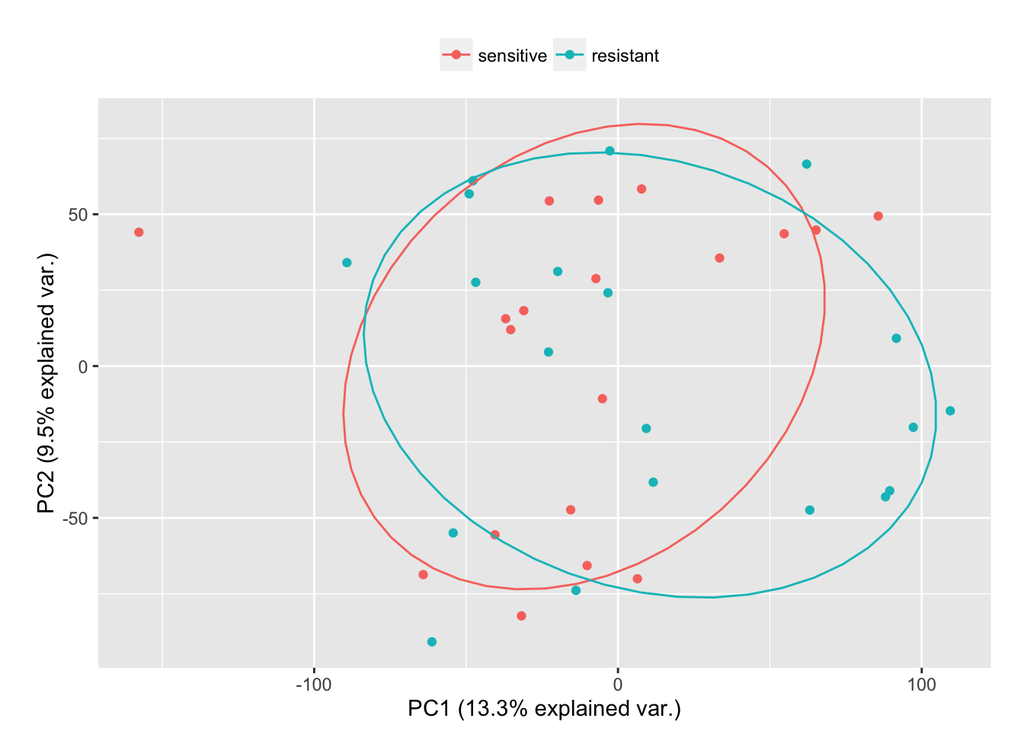

```r
# Get ggbiplot from Github if needed
# library(devtools)
# install_github("vqv/ggbiplot")

# Categorize drug response for coloring the plot
# Less than median GI50 = sensitive; greater than median = resistant
response.groups <- factor(drug7.response >= median(drug7.response), labels = c('sensitive', 'resistant'))

# Plot PCA with ggbiplot
library(ggbiplot)
g <- ggbiplot(expression.pca, obs.scale = 1, var.scale = 1,
              groups = response.groups, ellipse = TRUE,
              var.axes = F, circle = TRUE)
g <- g + scale_color_discrete(name = '')
g <- g + theme(legend.direction = 'horizontal',
               legend.position = 'top')
print(g)
```

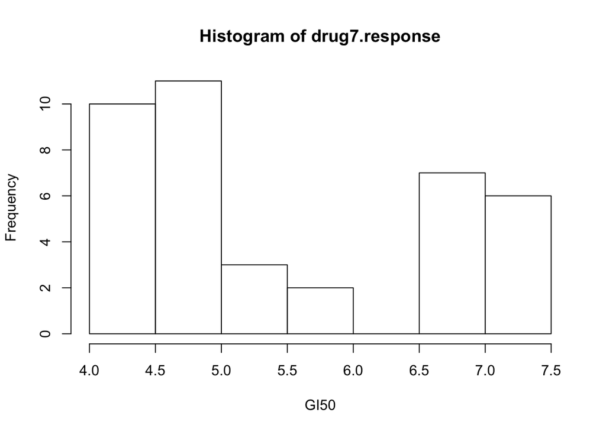

```r
# We could also try separating the groups more based on response distribution
hist(drug7.response, xlab = 'GI50')
```

[figure not shown]

```r
response.groups <- factor(cut(drug7.response,
                       breaks = c(0, 4.2, 6.7, 7.1),
                       labels = c('sensitive', 'average', 'resistant')))

g <- ggbiplot(expression.pca, obs.scale = 1, var.scale = 1,
              groups = response.groups, ellipse = TRUE,
              var.axes = F, circle = TRUE)
g <- g + scale_color_discrete(name = '')
g <- g + theme(legend.direction = 'horizontal',
               legend.position = 'top')
print(g)
```

```r
# Summarize each of the 39 principal components
summary(expression.pca)
```

```
## Importance of components:
##                            PC1      PC2      PC3      PC4      PC5
## Standard deviation     58.0992 49.09948 42.27047 33.63361 32.90872
## Proportion of Variance  0.1326  0.09468  0.07017  0.04443  0.04253
## Cumulative Proportion   0.1326  0.22724  0.29741  0.34184  0.38437
##                             PC6      PC7      PC8      PC9     PC10
## Standard deviation     29.73150 29.29570 28.30567 27.49166 25.82389
## Proportion of Variance  0.03472  0.03371  0.03147  0.02968  0.02619
## Cumulative Proportion   0.41909  0.45279  0.48426  0.51394  0.54013
##                            PC11     PC12     PC13     PC14     PC15
## Standard deviation     25.24812 24.84510 24.61081 23.74253 23.41688
## Proportion of Variance  0.02504  0.02424  0.02379  0.02214  0.02154
## Cumulative Proportion   0.56517  0.58941  0.61319  0.63533  0.65687
##                            PC16     PC17     PC18     PC19     PC20
## Standard deviation     23.05176 22.61060 22.49068 22.07754 21.86487
## Proportion of Variance  0.02087  0.02008  0.01987  0.01914  0.01878
## Cumulative Proportion   0.67774  0.69781  0.71768  0.73682  0.75560
##                            PC21     PC22     PC23    PC24     PC25
## Standard deviation     21.58974 21.28485 20.94318 20.6856 20.64223
## Proportion of Variance  0.01831  0.01779  0.01723  0.0168  0.01673
## Cumulative Proportion   0.77390  0.79170  0.80892  0.8257  0.84246
##                            PC26    PC27     PC28     PC29     PC30
## Standard deviation     20.52141 19.9274 19.43080 19.31156 18.87641
## Proportion of Variance  0.01654  0.0156  0.01483  0.01465  0.01399
## Cumulative Proportion   0.85900  0.8746  0.88942  0.90407  0.91806
##                            PC31     PC32     PC33     PC34     PC35
## Standard deviation     18.52356 17.57237 17.28959 16.70988 16.07912
## Proportion of Variance  0.01348  0.01213  0.01174  0.01097  0.01015
## Cumulative Proportion   0.93154  0.94366  0.95540  0.96637  0.97652
##                            PC36     PC37     PC38      PC39
## Standard deviation     15.43861 14.54603 12.15994 6.487e-13
## Proportion of Variance  0.00936  0.00831  0.00581 0.000e+00
## Cumulative Proportion   0.98588  0.99419  1.00000 1.000e+00
```

### Comparison with/without PCA

```r
# Mean squared error
MSE <- function(yhat, y){
    squared.error <- sum(mapply(function(yhat,y) (yhat-y)^2, yhat, y))
    return(squared.error/length(yhat))
}

# Make train and test sets
train = cell.lines %in% sample(cell.lines, 20)
test = !train

# Feature matrix made from 29 random genes
old.feature.matrix <- expression.data[,sample(29)]
old.combined <- cbind(old.feature.matrix, Response = drug7.response)
old.lm <- lm(Response ~ ., old.combined[train,])
MSE(predict(old.lm, old.combined[test,], type="response"), old.combined[test, 'Response'])
```

```
## [1] 2933.428
```

```r
# New feature matrix made from 29 PCs
new.feature.matrix <- data.frame(expression.pca$x[,1:29])
new.combined <- cbind(new.feature.matrix, Response = drug7.response)
new.lm <- lm(Response ~ ., new.combined[train,])
MSE(predict(new.lm, new.combined[test,], type="response"), new.combined[test, 'Response'])
```

```
## [1] 76.16835
```

#### TODO

Apply PCA to your new data set for the presentation on Thursday. How many principal components are required to explain 90% of the variance? Evaluate the effect of performing PCA on your results. Can you relate/correlate any of the principal components with the underlying biology (or other applicable data type)?